# R Notebook

#3 Data Frames

```r
medals <-data.frame(Country =c("NOR","GER","CHR"),
      Gold =c(16,12,9),
      Silver =c(8,10,4),
      Bronze =c(13,5,2))
medals
```

| Country | Gold | Silver | Bronze |
| --- | --- | --- | --- |
| NOR | 16 | 8 | 13 |
| GER | 12 | 10 | 5 |
| CHR | 9 | 4 | 2 |

1.Select the first and third rows and the first and third columns: select only col: medals(c(1,3)) select only rows: medals(c(1,3),)

```r
medals[c(1,3),c(1,3)]
```

|  | Country | Silver |
| --- | --- | --- |
| 1 | NOR | 8 |
| 3 | CHR | 4 |

2.Return a data frame that contains just the CHN row

```r
medals[3,]
```

|  | Country | Gold | Silver | Bronze |
| --- | --- | --- | --- | --- |
| 3 | CHR | 9 | 4 | 2 |

3.Return a data frame that contains the medals of Norway and Germany

```r
medals[c(1,2),]
```

|  | Country | Gold | Silver | Bronze |
| --- | --- | --- | --- | --- |
| 1 | NOR | 16 | 8 | 13 |
| 2 | GER | 12 | 10 | 5 |

4.select countries who won ten or more gold medals and return the country and gold columns using the subset() function

```r
subset(medals,Gold>= 10 )
```

|  | Country | Gold | Silver | Bronze |
| --- | --- | --- | --- | --- |
| 1 | NOR | 16 | 8 | 13 |
| 2 | GER | 12 | 10 | 5 |

5.Sort the medals by bronze(descending)

```r
medals[order(medals$Bronze,decreasing = TRUE),]
```

|  | Country | Gold | Silver | Bronze |
| --- | --- | --- | --- | --- |
| 1 | NOR | 16 | 8 | 13 |
| 2 | GER | 12 | 10 | 5 |
| 3 | CHR | 9 | 4 | 2 |

changing working directory :

```r
getwd()
```

```
[1] "C:/Users/Saturn/Desktop/DATA_SCIENCE_UNI"
```

```r
setwd("C:/Users/Saturn/Desktop/DATA_SCIENCE_UNI")
getwd()
```

```
[1] "C:/Users/Saturn/Desktop/DATA_SCIENCE_UNI"
```

1. Scaling up

```r
beijing2022 <- read.csv("Beijing2022.csv", sep = ";")
beijing2022
```

| Country | Gold | Silver | Bronze |
| --- | --- | --- | --- |
| Norway | 16 | 8 | 13 |
| Germany | 12 | 10 | 5 |
| China | 9 | 4 | 2 |
| United States | 8 | 10 | 7 |
| Sweden | 8 | 5 | 5 |
| Netherlands | 8 | 5 | 4 |
| Austria | 7 | 7 | 4 |
| Switzerland | 7 | 2 | 5 |
| ROC | 6 | 12 | 14 |
| France | 5 | 7 | 2 |

[output cut: 19 more lines]

1. compute the total number of medals won for each country and add this as a fifth column to the dataframe

```r
Total <- rowSums(beijing2022[c(2,3,4)])
beijing2022 <- cbind(beijing2022,Total)
beijing2022
```

| Country | Gold | Silver | Bronze | Total |
| --- | --- | --- | --- | --- |
| Norway | 16 | 8 | 13 | 37 |
| Germany | 12 | 10 | 5 | 27 |
| China | 9 | 4 | 2 | 15 |
| United States | 8 | 10 | 7 | 25 |
| Sweden | 8 | 5 | 5 | 18 |
| Netherlands | 8 | 5 | 4 | 17 |
| Austria | 7 | 7 | 4 | 18 |
| Switzerland | 7 | 2 | 5 | 14 |
| ROC | 6 | 12 | 14 | 32 |
| France | 5 | 7 | 2 | 14 |

[output cut: 19 more lines]

2.order the rows by the total number of medals won in descending order

```r
beijing2022 <- beijing2022[order(beijing2022$Total,decreasing = TRUE),]
beijing2022
```

|  | Country | Gold | Silver | Bronze | Total |
| --- | --- | --- | --- | --- | --- |
| 1 | Norway | 16 | 8 | 13 | 37 |
| 9 | ROC | 6 | 12 | 14 | 32 |
| 2 | Germany | 12 | 10 | 5 | 27 |
| 11 | Canada | 4 | 8 | 14 | 26 |
| 4 | United States | 8 | 10 | 7 | 25 |
| 5 | Sweden | 8 | 5 | 5 | 18 |
| 7 | Austria | 7 | 7 | 4 | 18 |
| 12 | Japan | 3 | 6 | 9 | 18 |
| 6 | Netherlands | 8 | 5 | 4 | 17 |
| 13 | Italy | 2 | 7 | 8 | 17 |

[output cut: 19 more lines]

3.Sort the data first by the number of total medals won and then by the number of gold medals won in descending order

```r
beijing2022 <- beijing2022[order(beijing2022$Total,beijing2022$Gold,decreasing = TRUE),]
beijing2022
```

|  | Country | Gold | Silver | Bronze | Total |
| --- | --- | --- | --- | --- | --- |
| 1 | Norway | 16 | 8 | 13 | 37 |
| 9 | ROC | 6 | 12 | 14 | 32 |
| 2 | Germany | 12 | 10 | 5 | 27 |
| 11 | Canada | 4 | 8 | 14 | 26 |
| 4 | United States | 8 | 10 | 7 | 25 |
| 5 | Sweden | 8 | 5 | 5 | 18 |
| 7 | Austria | 7 | 7 | 4 | 18 |
| 12 | Japan | 3 | 6 | 9 | 18 |
| 6 | Netherlands | 8 | 5 | 4 | 17 |
| 13 | Italy | 2 | 7 | 8 | 17 |

[output cut: 19 more lines]

4. Calculate the total number of cold, silver and bronze medals won at beijing 2022

```r
total_gold <- sum(beijing2022$Gold)
total_silver <- sum(beijing2022$Silver)
total_bronze<- sum(beijing2022$Bronze)
new_row <- data.frame(Country = "Total_medals",Gold = total_gold,Silver = total_silver, Bronze = total_bronze, Total=sum(beijing2022$Total) )
beijing2022<-rbind(beijing2022,new_row)
```

```r
beijing2022
```

|  | Country | Gold | Silver | Bronze | Total |
| --- | --- | --- | --- | --- | --- |
| 1 | Norway | 16 | 8 | 13 | 37 |
| 9 | ROC | 6 | 12 | 14 | 32 |
| 2 | Germany | 12 | 10 | 5 | 27 |
| 11 | Canada | 4 | 8 | 14 | 26 |
| 4 | United States | 8 | 10 | 7 | 25 |
| 5 | Sweden | 8 | 5 | 5 | 18 |
| 7 | Austria | 7 | 7 | 4 | 18 |
| 12 | Japan | 3 | 6 | 9 | 18 |
| 6 | Netherlands | 8 | 5 | 4 | 17 |
| 13 | Italy | 2 | 7 | 8 | 17 |

[output cut: 20 more lines]

5. the overall number of the medals won by all countries in the olypic games 2022 is 327

#4 Data exploration with R MASS is package containing a lot of datasets

```r
install.packages("MASS")
```

|  | binary | source | needs_compilation |
| --- | --- | --- | --- |
| MASS | 7.3-54 | 7.3-58.3 | TRUE |

```
  Binaries will be installed
```

```r
data("women")
women
```

| height | weight |
| --- | --- |
| 58 | 115 |
| 59 | 117 |
| 60 | 120 |
| 61 | 123 |
| 62 | 126 |
| 63 | 129 |
| 64 | 132 |
| 65 | 135 |
| 66 | 139 |
| 67 | 142 |

[output cut: 5 more lines]

```r
summary(women)
```

```
     height         weight
 Min.   :58.0   Min.   :115.0
 1st Qu.:61.5   1st Qu.:124.5
 Median :65.0   Median :135.0
 Mean   :65.0   Mean   :136.7
 3rd Qu.:68.5   3rd Qu.:148.0
 Max.   :72.0   Max.   :164.0
```

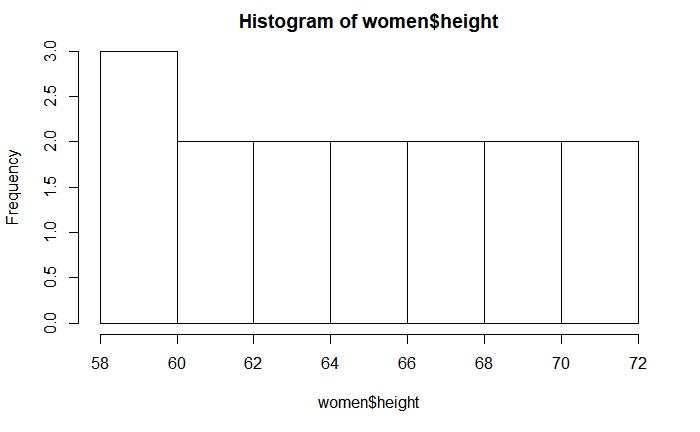

```r
hist(women$height)
```

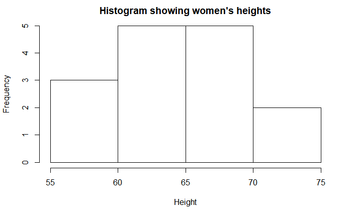

```r
hist(x= women$height, breaks=4, main="Histogram showing women's heights",xlab= "Height")
```

mfrow =c(1,2) means we want to put 2 plots like in the following illustration

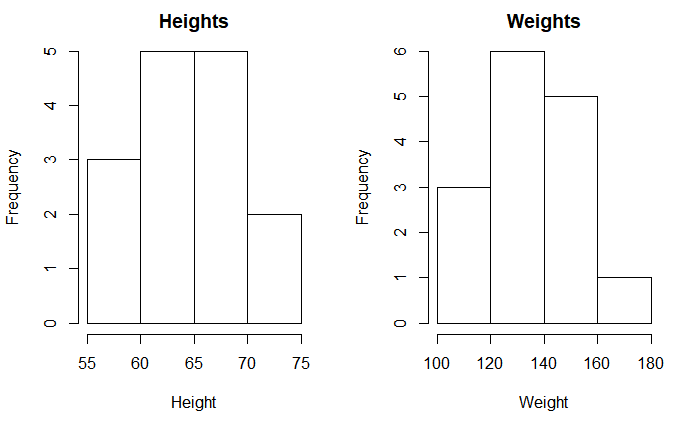

```r
par ( mfrow = c (1 ,2))
hist ( x = women $ height , breaks =4 , main = " Heights " , xlab = " Height " )
hist ( x = women $ weight , breaks =2 , main = " Weights " , xlab = " Weight " )
```

if we want our window just displaying one graph at a time:

```r
par(mfrow=c(1,1))
```

default scatterplot :

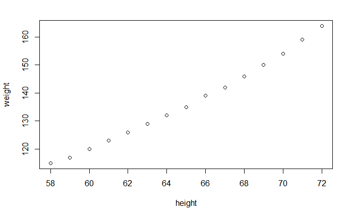

```r
plot(women)
```